# D607 - Assignment 3 - Normalization and Reg Exp

Marco Castro

2024-09-21

# Overview

For assignment #3, we focused on normalization and regular expressions.

## 1. Normalization

```r
# create division tibble
division <- tribble(
  ~division_id, ~league, ~division,
  "ALE", "American", "East",
  "ALC", "American", "Central",
  "ALW", "American", "West",
  "NLE", "National", "East",
  "NLC", "National", "Central",
  "NLW", "National", "West"
)

# create teams tibble
teams <- tribble(
  ~team_id, ~name, ~division,
  "PHI", "Phillies", "NLE",
  "NYM", "Mets", "NLE",
  "TOR", "Blue Jays", "ALE",
  "TB", "Rays", "ALE",
  "BAL", "Orioles", "ALE",
  "DET", "Tigers", "ALC",
  "WSH", "Nationals", "NLE",
  "CHC", "Cubs", "NLC",
  "CIN", "Reds",  "NLC",
  "PIT", "Pirates",  "NLC"
)

# create stadium tibble
stadium <- tribble(
  ~team_id, ~stadium, ~address, ~city, ~state,
  "PHI", "Citizens Bank Park","1 Citizens Bank Way","Philadelphia","PA",
  "NYM", "Citi Field", "41 Seaver Wy", "Flushing", "NY",
  "TOR", "Rogers Center","1 Blue Jays Way", "Toronto", "ON",
  "TB", "Tropicana Field","1 Tropicana Dr.","Tampa Bay", "FL",
  "BAL", "Camden Yards","333 W Camden St", "Baltimore", "MD",
  "DET", "Comerica Park","2100 Woodward Ave", "Detroit", "MI",
  "WSH", "Nationals Park", "1500 South Capitol St SE", "Washington", "DC",
  "CHC", "Wrigley Field","1060 W Addison St", "Chicago", "IL",
  "CIN", "Great American Ball Park", "100 Joe Nuxhall Wy", "Cincinnati", "OH",
  "PIT", "PNC Park", "115 Federal St", "Pittsburgh", "PA"
)

# create games tibble
games <- tribble(
  ~game_id, ~date, ~visitor, ~home, ~visitor_score, ~home_score,
  1, "2024-09-18", "PIT", "CIN", 3, 4,
  2, "2024-09-18", "WSH", "CHC", 7, 2,
  3, "2024-09-18", "DET", "BAL", 1, 0,
  4, "2024-09-18", "TOR", "TB", 2, 3,
  5, "2024-09-18", "PHI", "NYM", 4, 3,
  6, "2024-09-19", "PIT", "CIN", 1, 2,
  7, "2024-09-19", "WSH", "CHC", 2, 0,
  8, "2024-09-19", "DET", "BAL", 2, 3,
  9, "2024-09-19", "TOR", "TB", 1, 5,
  10, "2024-09-19", "PHI", "NYM", 8, 10,
  11, "2024-09-20", "PIT", "CIN", 2, 3,
  12, "2024-09-20", "WSH", "CHC", 2, 6,
  13, "2024-09-20", "DET", "BAL", 4, 1,
  14, "2024-09-20", "TOR", "TB", 5, 3,
  15, "2024-09-20", "PHI", "NYM", 2, 12,
  16, "2024-09-21", "PIT", "CIN", 1, 7,
  17, "2024-09-21", "WSH", "CHC", 5, 1,
  18, "2024-09-21", "DET", "BAL", 6, 4,
  19, "2024-09-21", "TOR", "TB", 2, 3,
  20, "2024-09-21", "PHI", "NYM", 3, 6,
)
```

Next I joined the dataframes using left joins. Repeating columns such as team “name” were renamed for clarity of wether a team was the home team hosting the game at their stadium or a visitor.

```r
games_in_series <- games |>
  left_join(teams, join_by(home == team_id)) |>
  left_join(teams, join_by(visitor == team_id)) |>
  left_join(stadium, join_by(home == team_id)) |>
  left_join(division, join_by(division.x == division_id)) |>
  left_join(division, join_by(division.y == division_id)) |>
  select(date, home_score, visitor_score, name.x, league.x, division.x, name.y, league.y, division.y, stadium, address, city, state) |>
  rename(
    home_team = name.x,
    home_league = league.x,
    home_division = division.x,
    visitor_team = name.y,
    visitor_league = league.y,
    visitor_division = division.y,
    played_at = stadium
  )
```

```r
runs_scored_in_series <- games_in_series |>
  mutate(teams = paste(visitor_team, home_team, sep=" at ")) |>
  group_by(teams) |>
  summarise(
    runs_home_team = sum(home_score),
    runs_visitor_team = sum(visitor_score)
  )

runs_scored_in_series
```

| teams | runs_home_team | runs_visitor_team |
| --- | --- | --- |
| Blue Jays at Rays | 14 | 10 |
| Nationals at Cubs | 9 | 16 |
| Phillies at Mets | 31 | 17 |
| Pirates at Reds | 16 | 7 |
| Tigers at Orioles | 8 | 13 |

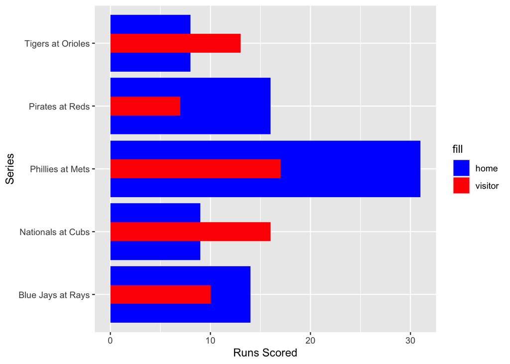

```r
runs_scored_in_series |>
  ggplot(aes(x=teams)) +
    coord_flip() +
    geom_bar(stat='identity', aes(y=runs_home_team, fill=
                     "blue")) +
    geom_bar(stat='identity', aes(y=runs_visitor_team, width = 0.3, fill=
                     "red")) +
    labs(x="Series", y = 'Runs Scored') +
    scale_fill_manual(values = c("blue","red"),labels = c("home","visitor"))
```

## Regular expression

This section focuses on using regular expressions.

### 2. Character Manipulation

We were asked to download a dataset showing 175 college majors from Five Thirty Eight (https://fivethirtyeight.com/features/the-economic-guide-to-picking-a-college-major/) and identify the majors containing “DATA” or “STATISTICS” in their names.

```r
# load data from 538 github page
college_majors <- read_csv("https://raw.githubusercontent.com/fivethirtyeight/data/refs/heads/master/college-majors/majors-list.csv")

# filter df where majors contain "DATA" OR "STATISTICS" using str_detect
college_majors_data_statistics <- college_majors |>
  filter(str_detect(Major, "DATA|STATISTICS"))

# filter df where majors contain "DATA" OR "STATISTICS" using GREPL
college_majors_data_statistics_grepl <- college_majors |>
  filter(grepl("DATA|STATISTICS", Major))
```

Using the function *str_detect* within a filter, I was able to determine that the majors with those keywords are:

| FOD1P | Major | Major_Category |
| --- | --- | --- |
| 6212 | MANAGEMENT INFORMATION SYSTEMS AND STATISTICS | Business |
| 2101 | COMPUTER PROGRAMMING AND DATA PROCESSING | Computers & Mathematics |
| 3702 | STATISTICS AND DECISION SCIENCE | Computers & Mathematics |

For comparison, I also attempted to filter using grepl and achived the same results

| FOD1P | Major | Major_Category |
| --- | --- | --- |
| 6212 | MANAGEMENT INFORMATION SYSTEMS AND STATISTICS | Business |
| 2101 | COMPUTER PROGRAMMING AND DATA PROCESSING | Computers & Mathematics |
| 3702 | STATISTICS AND DECISION SCIENCE | Computers & Mathematics |

### 3. Description of expressions:

We were asked to define the following regular expressions:

```r
p1 <- "(.)\1"
p2 <- "(.)(.)\\2\\1"
p3 <- "(..)\1"
p4 <- "(.).\\1.\\1"
p5 <- "(.)(.)(.).*\\3\\2\\1"
```

*a: (.)\1\1* Returns true if string contains any characters followed by \1. For example “T\1” or “e\1” in the code block below:

```r
test_str <- c('T\1sxded', 'apple\1', 'carrot', '\1brocoli', 'banana')
str_detect(test_str, p1)
```

```
## [1]  TRUE  TRUE FALSE FALSE FALSE
```

*b: “(.)(.)\2\1”* Returns true if string two characters followed by the same two characters reordered from last to first. For example: “xssx” or “anna” in the code block below:

```r
test_str <- c("TsxssxT", 'apple\1', 'carrot', '\1brocoli', 'bananna')
str_detect(test_str, p2)
```

```
## [1]  TRUE FALSE FALSE FALSE  TRUE
```

*c: (..)\1* Returns true if string contains two characters followed by \1. For example “Ts\1” or “le1” in the code block below:

```r
test_str <- c('TsTs\1sxded', 'apple\1', 'carrot', '\1brocoli', 'banana')
str_detect(test_str, p3)
```

```
## [1]  TRUE  TRUE FALSE FALSE FALSE
```

*d: “(.).\1.\1”* Returns true if string contains a character followed by any character, repeats the first character followed by any character, then repeats the first character again. For example: “AbAcA” in the code block below:

```r
test_str <- c( 'AbAcA', 'apple\1', 'AbAcA', '\1brocoli', 'banana')
str_detect(test_str, p4)
```

```
## [1]  TRUE FALSE  TRUE FALSE  TRUE
```

_e: “(.)(.)(.).*\3\2\1”_ Returns true if string contains three characters (ABC in my example), followed by 0 or more characters, then repeats the first three characters in the matching expression in reverse order. For example: “ABCsomethingCBA” in the code block below or “ABCsCBA, or”ABCCBA.”

```r
test_str <- c('ABCsomethingCBA', 'apple\1', 'carrot', '\1brocoli', 'banana')
str_detect(test_str, p5)
```

```
## [1]  TRUE FALSE FALSE FALSE FALSE
```

### 4. Constructing regular expressions

We were asked to construct regular expressions for the following conditions:

*a: Start and end with the same character* (.).+\1

```r
str_detect("xHellox", "(.).+\\1")
```

```
## [1] TRUE
```

*b: Contain a repeated pair of letters (e.g. “church” contains “ch” repeated twice.)* (..).+\1

```r
str_detect("church", "(..).+\\1")
```

```
## [1] TRUE
```

*c: Contain one letter repeated in at least three places (e.g. “eleven” contains three “e”s.)*

(.).\1.\1

```r
str_detect(c("eleven","bananas"), "(.).\\1.\\1")
```

```
## [1] TRUE TRUE
```

## Conclusion

Regular expressions are a powerful tool that will come in handy.